# Multi-dimensional Regression Model: Pandemic and Bike Rents in London

Leti Mei

```r
install.packages("tidyverse")
install.packages("emmeans")
install.packages("Hmisc")
install.packages("car")
install.packages("RColorBrewer")
install.packages("gridExtra")
install.packages("ggpubr")


library(tidyverse)
library(emmeans) # for emmeans() and pairs()
library(Hmisc) # for correlation functions
library(car) # for vif()
library(RColorBrewer)
library(gridExtra)
library(ggpubr)
```

```r
# Read in the datafile "London_COVID_bikes.csv"
data <- read_csv("London_COVID_bikes.csv")
```

### Data Dictionary

| Variable (Restriction Policy) | Description |
| --- | --- |
| School closures | Complete closures only |
| Pub closures | Excluding pubs that serve food |
| Shop closures | Non-essential shops only |
| Eating Places closures | Including pubs that serve food |
| Stay at home orders | When people are ordered to stay at homes, started on 2020-03-23 |
| Household mixing indoors banned | Household mixing rules have been imposed to prevent people who do not live together from meeting. |
| Working from home encouraged (wfh) | When working from home is encouraged, first advised on 2020-03-17 |
| Rule of 6 indoors | When people were prohibited from meeting more than six people socially, first announced on 2020-09-14 and implemented on 2020-09-22 |
| 10pm curfew on hospitality (curfew) | All hospitality venues must shut at 10pm |
| Eat Out to Help Out scheme | From 3 to 31 August, 2020, get a 50% discount when you eat in at restaurants that are registered with the Eat Out to Help Out Scheme |

### Data Exploration

We first start the exploration of data by checking its structure, summary, and whether there is any missing values contained.

```r
# Check the structure and summary of the data
str(data)
```

```
## spc_tbl_ [4,812 × 15] (S3: spec_tbl_df/tbl_df/tbl/data.frame)
##  $ date                           : Date[1:4812], format: "2010-07-30" "2010-07-31" ...
##  $ Hires                          : num [1:4812] 6897 5564 4303 6642 7966 ...
##  $ schools_closed                 : num [1:4812] 0 0 0 0 0 0 0 0 0 0 ...
##  $ pubs_closed                    : num [1:4812] 0 0 0 0 0 0 0 0 0 0 ...
##  $ shops_closed                   : num [1:4812] 0 0 0 0 0 0 0 0 0 0 ...
##  $ eating_places_closed           : num [1:4812] 0 0 0 0 0 0 0 0 0 0 ...
##  $ stay_at_home                   : num [1:4812] 0 0 0 0 0 0 0 0 0 0 ...
##  $ household_mixing_indoors_banned: num [1:4812] 0 0 0 0 0 0 0 0 0 0 ...
##  $ wfh                            : num [1:4812] 0 0 0 0 0 0 0 0 0 0 ...
##  $ rule_of_6_indoors              : num [1:4812] 0 0 0 0 0 0 0 0 0 0 ...
##  $ curfew                         : num [1:4812] 0 0 0 0 0 0 0 0 0 0 ...
##  $ eat_out_to_help_out            : num [1:4812] 0 0 0 0 0 0 0 0 0 0 ...
##  $ day                            : chr [1:4812] "Fri" "Sat" "Sun" "Mon" ...
##  $ month                          : chr [1:4812] "Jul" "Jul" "Aug" "Aug" ...
##  $ year                           : num [1:4812] 2010 2010 2010 2010 2010 2010 2010 2010 2010 2010 ...
##  - attr(*, "spec")=
##   .. cols(
##   ..   date = col_date(format = ""),
##   ..   Hires = col_double(),
##   ..   schools_closed = col_double(),
##   ..   pubs_closed = col_double(),
##   ..   shops_closed = col_double(),
##   ..   eating_places_closed = col_double(),
##   ..   stay_at_home = col_double(),
##   ..   household_mixing_indoors_banned = col_double(),
##   ..   wfh = col_double(),
##   ..   rule_of_6_indoors = col_double(),
##   ..   curfew = col_double(),
##   ..   eat_out_to_help_out = col_double(),
##   ..   day = col_character(),
##   ..   month = col_character(),
##   ..   year = col_double()
##   .. )
##  - attr(*, "problems")=<externalptr>
```

```r
summary(data)
```

```
##       date                Hires       schools_closed     pubs_closed
##  Min.   :2010-07-30   Min.   :    0   Min.   :0.00000   Min.   :0.00000
##  1st Qu.:2013-11-13   1st Qu.:19776   1st Qu.:0.00000   1st Qu.:0.00000
##  Median :2017-02-28   Median :26356   Median :0.00000   Median :0.00000
##  Mean   :2017-02-28   Mean   :26607   Mean   :0.02743   Mean   :0.05175
##  3rd Qu.:2020-06-15   3rd Qu.:33481   3rd Qu.:0.00000   3rd Qu.:0.00000
##  Max.   :2023-09-30   Max.   :73094   Max.   :1.00000   Max.   :1.00000
##   shops_closed     eating_places_closed  stay_at_home
##  Min.   :0.00000   Min.   :0.00000      Min.   :0.00000
##  1st Qu.:0.00000   1st Qu.:0.00000      1st Qu.:0.00000
##  Median :0.00000   Median :0.00000      Median :0.00000
##  Mean   :0.04634   Mean   :0.05175      Mean   :0.03616
##  3rd Qu.:0.00000   3rd Qu.:0.00000      3rd Qu.:0.00000
##  Max.   :1.00000   Max.   :1.00000      Max.   :1.00000
##  household_mixing_indoors_banned      wfh         rule_of_6_indoors
##  Min.   :0.00000                 Min.   :0.0000   Min.   :0.00000
##  1st Qu.:0.00000                 1st Qu.:0.0000   1st Qu.:0.00000
##  Median :0.00000                 Median :0.0000   Median :0.00000
##  Mean   :0.06525                 Mean   :0.2273   Mean   :0.01995
##  3rd Qu.:0.00000                 3rd Qu.:0.0000   3rd Qu.:0.00000
##  Max.   :1.00000                 Max.   :1.0000   Max.   :1.00000
##      curfew        eat_out_to_help_out     day               month
##  Min.   :0.00000   Min.   :0.000000    Length:4812        Length:4812
##  1st Qu.:0.00000   1st Qu.:0.000000    Class :character   Class :character
##  Median :0.00000   Median :0.000000    Mode  :character   Mode  :character
##  Mean   :0.01164   Mean   :0.005819
##  3rd Qu.:0.00000   3rd Qu.:0.000000
##  Max.   :1.00000   Max.   :1.000000
##       year
##  Min.   :2010
##  1st Qu.:2013
##  Median :2017
##  Mean   :2017
##  3rd Qu.:2020
##  Max.   :2023
```

```r
summarise_all(data, ~ sum(is.na(.x))) # no missing value contained
```

```
## # A tibble: 1 × 15
##    date Hires schools_closed pubs_closed shops_closed eating_places_closed
##   <int> <int>          <int>       <int>        <int>                <int>
## 1     0     0              0           0            0                    0
## # ℹ 9 more variables: stay_at_home <int>,
## #   household_mixing_indoors_banned <int>, wfh <int>, rule_of_6_indoors <int>,
## #   curfew <int>, eat_out_to_help_out <int>, day <int>, month <int>, year <int>
```

The data structure indicates that most of the variables are numerical data except variables “day” and “month”, which are characters. The earliest record in this data is on 2010-07-30, and the last record is on 2023-09-30, as we can learn from the summary. There is no missing value contained in the data.

Then, we convert time variables (day, month, year) into factors with appropriate levels.

```r
# Check for unique month inputs and see if there's upper and lower case inconsistency issue (e.g. Jul and jul would be identified as two distinct inputs).
unique(data$month)
```

```
##  [1] "Jul" "Aug" "Sep" "Oct" "Nov" "Dec" "Jan" "Feb" "Mar" "Apr" "May" "Jun"
```

```r
# Check for unique day inputs and see if there's upper and lower case inconsistency issue.
unique(data$day)
```

```
## [1] "Fri" "Sat" "Sun" "Mon" "Tue" "Wed" "Thu"
```

```r
# Convert "month" variable into factor with appropriate levels
data <- data %>% mutate(month=factor(month, levels=c("Jan", "Feb", "Mar", "Apr", "May", "Jun", "Jul", "Aug", "Sep", "Oct", "Nov", "Dec")))

# Convert "day" variable into factor with appropriate levels
data <- data %>% mutate(day=factor(day, levels=c("Mon", "Tue", "Wed", "Thu", "Fri", "Sat", "Sun")))

# Convert "year" variable into factors; since years are in numeric form so we do not have to re-specify the levels.
data$year <- as.factor(data$year)

# Check the data summary again and see if the data type of these three time variables are changed successfully.
summary(data)
```

```
##       date                Hires       schools_closed     pubs_closed
##  Min.   :2010-07-30   Min.   :    0   Min.   :0.00000   Min.   :0.00000
##  1st Qu.:2013-11-13   1st Qu.:19776   1st Qu.:0.00000   1st Qu.:0.00000
##  Median :2017-02-28   Median :26356   Median :0.00000   Median :0.00000
##  Mean   :2017-02-28   Mean   :26607   Mean   :0.02743   Mean   :0.05175
##  3rd Qu.:2020-06-15   3rd Qu.:33481   3rd Qu.:0.00000   3rd Qu.:0.00000
##  Max.   :2023-09-30   Max.   :73094   Max.   :1.00000   Max.   :1.00000
##
##   shops_closed     eating_places_closed  stay_at_home
##  Min.   :0.00000   Min.   :0.00000      Min.   :0.00000
##  1st Qu.:0.00000   1st Qu.:0.00000      1st Qu.:0.00000
##  Median :0.00000   Median :0.00000      Median :0.00000
##  Mean   :0.04634   Mean   :0.05175      Mean   :0.03616
##  3rd Qu.:0.00000   3rd Qu.:0.00000      3rd Qu.:0.00000
##  Max.   :1.00000   Max.   :1.00000      Max.   :1.00000
##
##  household_mixing_indoors_banned      wfh         rule_of_6_indoors
##  Min.   :0.00000                 Min.   :0.0000   Min.   :0.00000
##  1st Qu.:0.00000                 1st Qu.:0.0000   1st Qu.:0.00000
##  Median :0.00000                 Median :0.0000   Median :0.00000
##  Mean   :0.06525                 Mean   :0.2273   Mean   :0.01995
##  3rd Qu.:0.00000                 3rd Qu.:0.0000   3rd Qu.:0.00000
##  Max.   :1.00000                 Max.   :1.0000   Max.   :1.00000
##
##      curfew        eat_out_to_help_out  day          month           year
##  Min.   :0.00000   Min.   :0.000000    Mon:688   Aug    : 434   2012   : 366
##  1st Qu.:0.00000   1st Qu.:0.000000    Tue:687   Sep    : 420   2016   : 366
##  Median :0.00000   Median :0.000000    Wed:687   Jul    : 405   2020   : 366
##  Mean   :0.01164   Mean   :0.005819    Thu:687   Dec    : 404   2021   : 366
##  3rd Qu.:0.00000   3rd Qu.:0.000000    Fri:688   Jan    : 403   2011   : 365
##  Max.   :1.00000   Max.   :1.000000    Sat:688   Mar    : 403   2013   : 365
##                                        Sun:687   (Other):2343   (Other):2618
```

After checking the data types, we move on to see the relationship between month and bike rents across 2010-2023.

```r
# Set colors to be used in the following visualizations
mycolors = c(brewer.pal(name="Dark2", n = 8), brewer.pal(name="Paired", n = 6))

# Calculate the monthly average bike hires data to be used in the visualization
monthly_avg <- data %>%
  group_by(year, month) %>%
  summarise(monthly_avg_hires = mean(Hires))
```

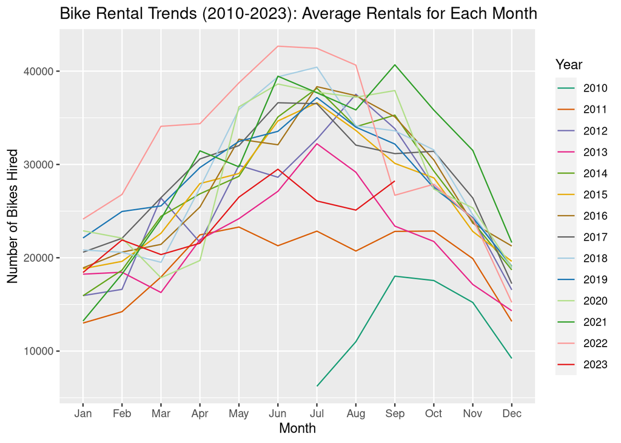

```r
# Plot the relationship between month and monthly average bike hires, with line color representing different years
ggplot(monthly_avg, aes(x=month, y=monthly_avg_hires, col=year, group=year)) +
  geom_line() +
  labs(title="Bike Rental Trends (2010-2023): Average Rentals for Each Month", x="Month", y="Number of Bikes Hired", col="Year")+
  scale_color_manual(values = mycolors)
```

Overall looking, the number of bikes hired seems to increase year by year; in each year, bike rents reach a peak usually in the middle of the year, and such figure is low at the beginning and ending of the year.

Then we can also review the relationship between weekday and bike rents across 2010-2023.

```r
# Calculate the average bike hires data for each weekday to be used in the visualization
weekday_avg <- data %>%
  group_by(year, day) %>%
  summarise(day_avg_hires = mean(Hires))
```

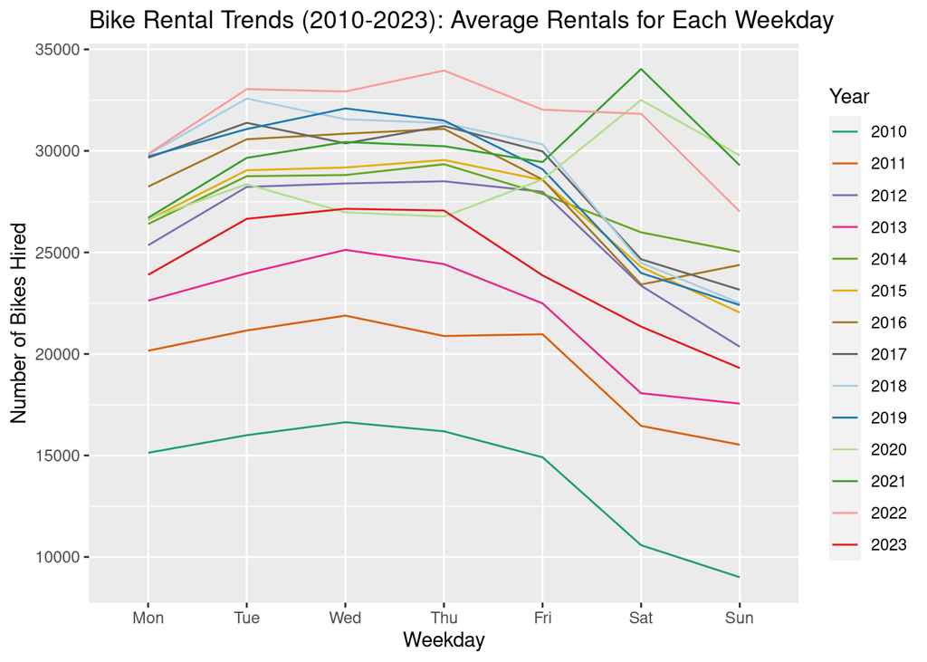

```r
# Plot the relationship between weekday and daily average bike hires, with line color representing different years
ggplot(weekday_avg, aes(x=day, y=day_avg_hires, col=year, group=year)) +
  geom_line() +
  labs(title="Bike Rental Trends (2010-2023): Average Rentals for Each Weekday",x="Weekday", y="Number of Bikes Hired", col="Year") +
  scale_color_manual(values = mycolors)
```

Again, we can see that the number of bikes hired seems to increase year by year; in each week, bike rents are lower on weekends (especially on Sunday) than on workdays.

Moreover, we can use the following graph to review the overall bike rental trend across years:

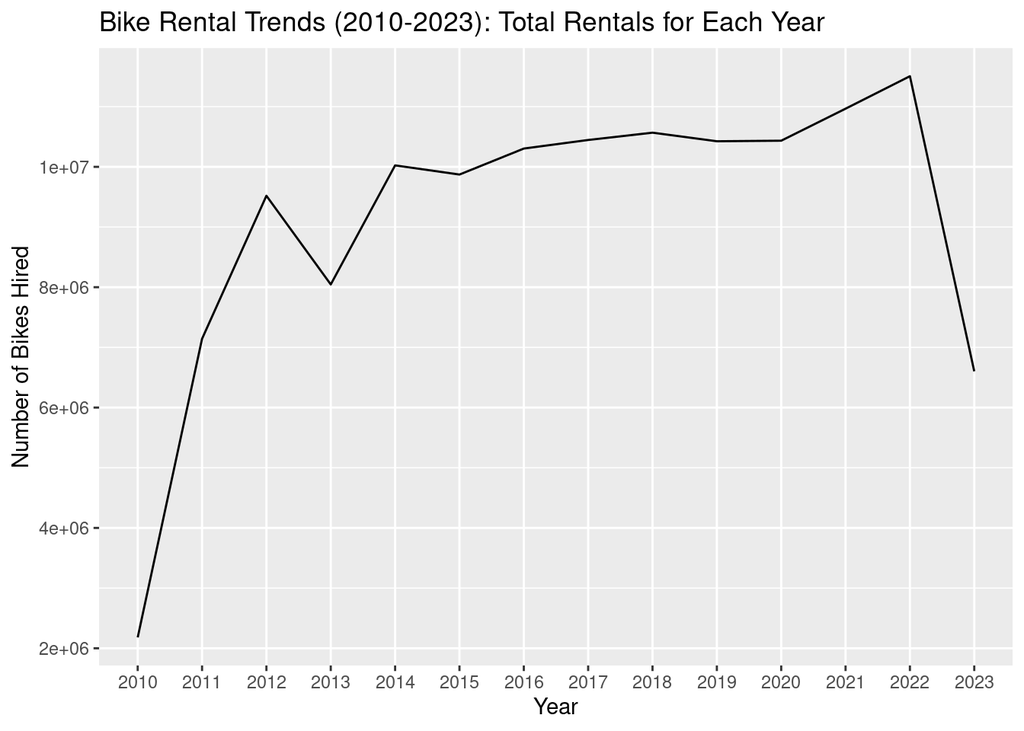

```r
# Calculate the yearly total bike rents
year_sum <- data %>%
  group_by(year) %>%
  summarise(total_hires = sum(Hires))

# Plot the summation out
ggplot(year_sum, aes(x=year, y=total_hires)) + geom_line(aes(group=1)) +
  labs(title="Bike Rental Trends (2010-2023): Total Rentals for Each Year",x="Year", y="Number of Bikes Hired")
```

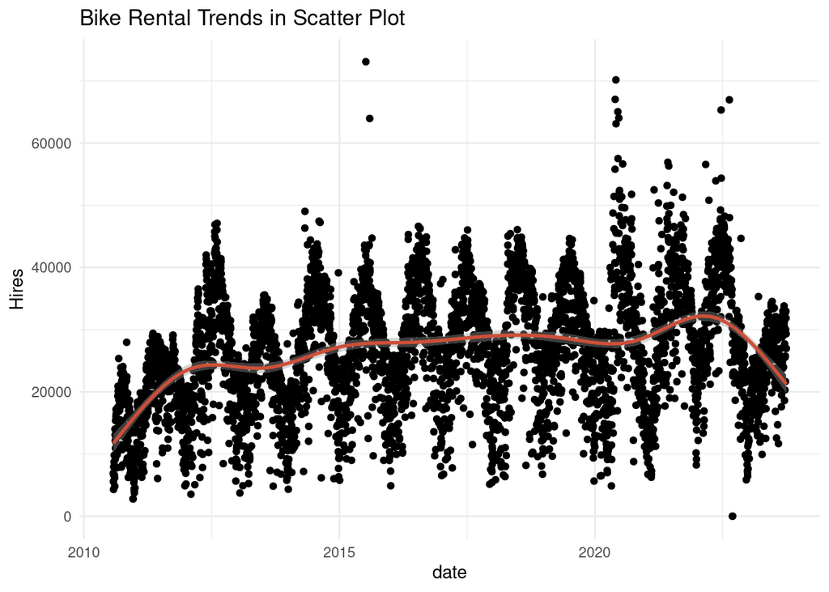

```r
# Plot the scatter graph as well to better understand the trend
ggplot(data, aes(y=Hires, x=date)) +
geom_jitter(width=0.1, height=0.1) + geom_smooth(color="tomato3")+
theme_minimal() + labs(title="Bike Rental Trends in Scatter Plot")
```

Bike rents increased at most of the years and reached the peak at 2022.

Since we are most interested in three variables- Rule of 6 indoors, Working from home, and Eat out to help out scheme- we can highlight them out on the scatter plot to better see their distribution.

```r
# create new columns with some variables being turned into factor to better visualize them
wfh_factor <- as.factor(data$wfh)
ro6_factor <- as.factor(data$rule_of_6_indoors)
eatout_factor <- as.factor(data$eat_out_to_help_out)
```

We first count the number of 0 and 1 instances in these variables to get a rough idea about the implementation frequency of these policies.

```r
# count the number of 0 and 1 instances
count(data, wfh)
```

```
## # A tibble: 2 × 2
##     wfh     n
##   <dbl> <int>
## 1     0  3718
## 2     1  1094
```

```r
count(data, rule_of_6_indoors)
```

```
## # A tibble: 2 × 2
##   rule_of_6_indoors     n
##               <dbl> <int>
## 1                 0  4716
## 2                 1    96
```

```r
count(data, eat_out_to_help_out)
```

```
## # A tibble: 2 × 2
##   eat_out_to_help_out     n
##                 <dbl> <int>
## 1                   0  4784
## 2                   1    28
```

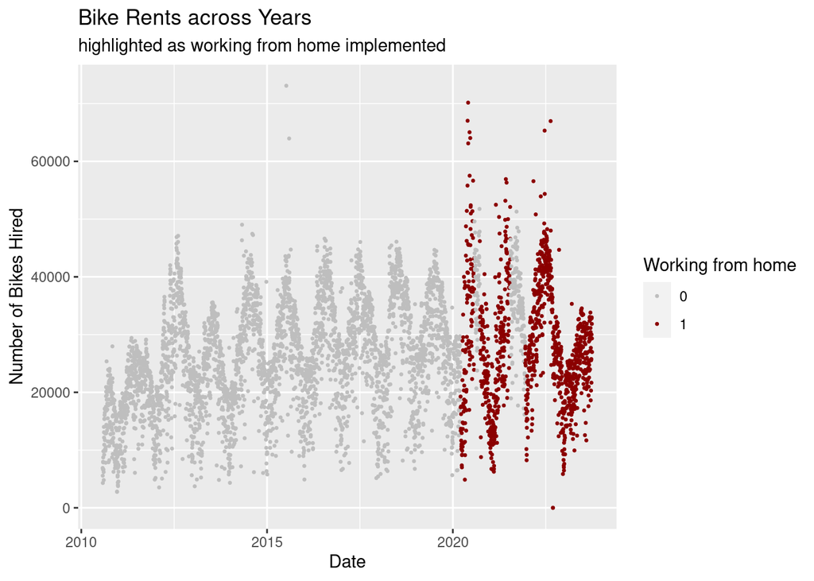

```r
ggplot(data, aes(y=Hires, x=date, color=wfh_factor)) + geom_jitter(width=0.1, height=0.1, size=0.5) + scale_color_manual(values = c("gray", "darkred")) + labs(x="Date", y="Number of Bikes Hired", col="Working from home") + labs(title="Bike Rents across Years", subtitle = "highlighted as working from home implemented")
```

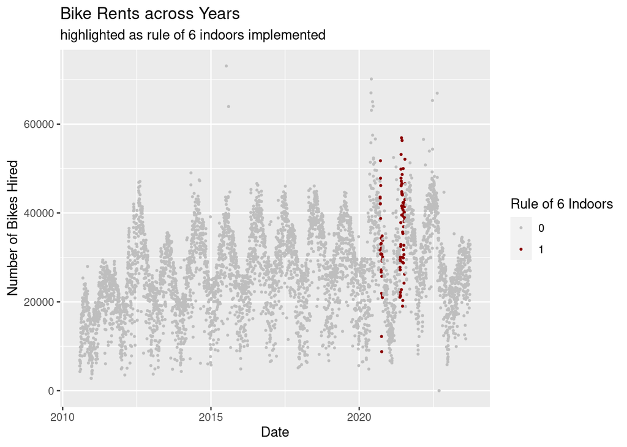

```r
ggplot(data, aes(y=Hires, x=date, color=ro6_factor)) + geom_jitter(width=0.1, height=0.1, size=0.5) + scale_color_manual(values = c("gray", "darkred")) + labs(x="Date", y="Number of Bikes Hired", col="Rule of 6 Indoors")+ labs(title="Bike Rents across Years", subtitle = "highlighted as rule of 6 indoors implemented")
```

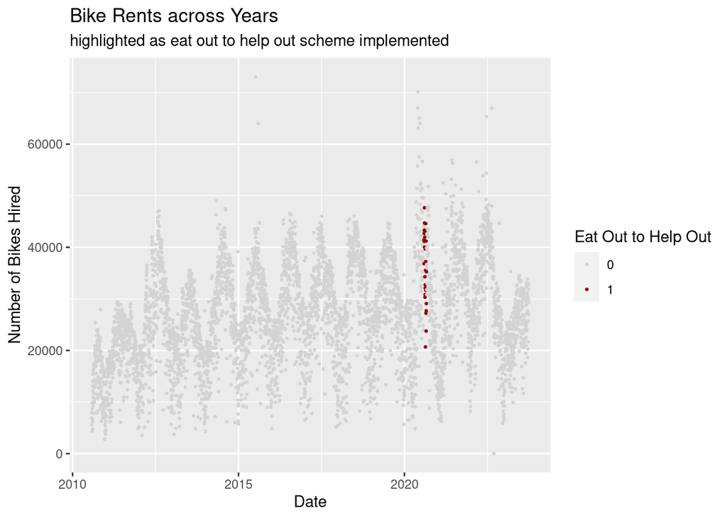

```r
ggplot(data, aes(y=Hires, x=date, color=eatout_factor)) + geom_jitter(width=0.1, height=0.1, size=0.5) + scale_color_manual(values = c("lightgray", "darkred")) + labs(x="Date", y="Number of Bikes Hired", col="Eat Out to Help Out")+ labs(title="Bike Rents across Years", subtitle = "highlighted as eat out to help out scheme implemented")
```

As we can see, working from home policy had been implemented all the way from early 2020 to the end of 3rd quarter in 2023, with 1094 records (days) of implementation. Rule of 6 indoors was started being implemented in the late 2020 and stopped in the mid-2021, with only 96 days of implementation. Eat out to help out scheme started from 3 to 31 August, 2020, with 28 days of implementation.

### Model Building

##### Regression model with time variables excluded

Before we start building the model, we first examine the pairwise correlations between each variable we have; if two variables are strongly correlated (either negatively or positively), our regression could be suffering from multicollinearity.

```r
rcorr(as.matrix(select_if(data, is.numeric)))
```

```
##                                 Hires schools_closed pubs_closed shops_closed
## Hires                            1.00          -0.09       -0.06        -0.08
## schools_closed                  -0.09           1.00        0.72         0.76
## pubs_closed                     -0.06           0.72        1.00         0.94
## shops_closed                    -0.08           0.76        0.94         1.00
## eating_places_closed            -0.06           0.72        1.00         0.94
## stay_at_home                    -0.15           0.72        0.83         0.88
## household_mixing_indoors_banned -0.04           0.63        0.87         0.83
## wfh                              0.08           0.31        0.43         0.41
## rule_of_6_indoors                0.13          -0.02       -0.03        -0.03
## curfew                           0.00          -0.02       -0.03        -0.02
## eat_out_to_help_out              0.08          -0.01       -0.02        -0.02
##                                 eating_places_closed stay_at_home
## Hires                                          -0.06        -0.15
## schools_closed                                  0.72         0.72
## pubs_closed                                     1.00         0.83
## shops_closed                                    0.94         0.88
## eating_places_closed                            1.00         0.83
## stay_at_home                                    0.83         1.00
## household_mixing_indoors_banned                 0.87         0.73
## wfh                                             0.43         0.36
## rule_of_6_indoors                              -0.03        -0.03
## curfew                                         -0.03        -0.02
## eat_out_to_help_out                            -0.02        -0.01
##                                 household_mixing_indoors_banned   wfh
## Hires                                                     -0.04  0.08
## schools_closed                                             0.63  0.31
## pubs_closed                                                0.87  0.43
## shops_closed                                               0.83  0.41
## eating_places_closed                                       0.87  0.43
## stay_at_home                                               0.73  0.36
## household_mixing_indoors_banned                            1.00  0.49
## wfh                                                        0.49  1.00
## rule_of_6_indoors                                         -0.04  0.23
## curfew                                                     0.23  0.20
## eat_out_to_help_out                                       -0.02 -0.04
##                                 rule_of_6_indoors curfew eat_out_to_help_out
## Hires                                        0.13   0.00                0.08
## schools_closed                              -0.02  -0.02               -0.01
## pubs_closed                                 -0.03  -0.03               -0.02
```

[output cut: 46 more lines]

```
## rule_of_6_indoors               0.0089                          0.0000
## curfew                          0.0000                          0.0000
## eat_out_to_help_out             0.1609                          0.0040
##                                 rule_of_6_indoors curfew eat_out_to_help_out
## Hires                           0.0000            0.9347 0.0000
## schools_closed                  0.0965            0.2063 0.3729
## pubs_closed                     0.0208            0.0787 0.2152
## shops_closed                    0.0291            0.0971 0.2421
## eating_places_closed            0.0208            0.0787 0.2152
## stay_at_home                    0.0553            0.1449 0.3041
## household_mixing_indoors_banned 0.0089            0.0000 0.1609
## wfh                             0.0000            0.0000 0.0040
## rule_of_6_indoors                                 0.0000 0.4491
## curfew                          0.0000                   0.5648
## eat_out_to_help_out             0.4491            0.5648
```

Some predictors have an extremely high r value (above 0.85): shops_closed and pubs_closed (0.94), eating_places_closed and pubs_closed (1.00), eating_places_closed and shops_closed (0.94), household_mixing_indoors_banned and pubs_closed (0.87), stay_at_home and shops_closed (0.88), household_mixing_indoors_banned and eating_places_closed (0.87).

It is worth mentioning that if we check the data dictionary again, we can see that eating_places_closed and pubs_closed are nested; eating place closures has already included pub closures, and that’s why their r value is 1. Thus, in order to prevent multicollinearity issues and isolate the individual effects of each variable, we retain the eating_places_closed variable and exclude the pubs_closed variable from our following model. As for other highly correlated variables, we will check their VIF score after building the model.

Here we are creating a model with variables that may have an effect on the dependent variable (number of bike rented). I am using all variables in the data to build the model because their occurrence can more or less affect the number of bike rented. For example, when working from home is encouraged, bike rents might decrease because the transportation need is weakened; this rationale can be extended to variables such as schools_closed, stay_at_home, and curfew. Also, since people might ride bikes to work on workdays, bike rents on working days might thus be higher than on weekends.

Since the variable “pubs closures” is already included in the variable “eating places closures”, I am only using the latter for model building.

```r
# Build the regression model with the above-mentioned variables used
m.hires <- lm(Hires~schools_closed+shops_closed+eating_places_closed+stay_at_home+household_mixing_indoors_banned+curfew+eat_out_to_help_out+wfh+rule_of_6_indoors, data=data)

# Check the VIF score and modify the model if we have variables with VIF>=5
vif(m.hires)
```

```
##                  schools_closed                    shops_closed
##                        2.403903                       13.193574
##            eating_places_closed                    stay_at_home
##                       12.870333                        4.516650
## household_mixing_indoors_banned                          curfew
##                        6.337655                        1.578761
##             eat_out_to_help_out                             wfh
##                        1.001727                        1.434432
##               rule_of_6_indoors
##                        1.242229
```

Not surprisingly, VIF scores are high for the eating_places_closed, shops_closed, and household_mixing_indoors_banned scores, suggesting multicollinearity and reflecting the high pairwise correlation between eating_places_closed and shops_closed, and between household_mixing_indoors_banned and eating_places_closed.

Since compare to other two variables, we tend to use eating_places_closed as a predictor in our model, we choose to exclude household_mixing_indoors_banned and shops_closed from the model.

Before removing household_mixing_indoors_banned and shops_closed, we can use one-way ANOVA to test whether these variables have significant effects on bike rents.

```r
# Conduct the ANOVA test
anova(m.hires)
```

```
## Analysis of Variance Table
##
## Response: Hires
##                                   Df     Sum Sq    Mean Sq  F value    Pr(>F)
## schools_closed                     1 3.7591e+09 3.7591e+09  42.9528 6.197e-11
## shops_closed                       1 1.5060e+08 1.5060e+08   1.7208    0.1897
## eating_places_closed               1 1.4210e+09 1.4210e+09  16.2365 5.677e-05
## stay_at_home                       1 1.0895e+10 1.0895e+10 124.4865 < 2.2e-16
## household_mixing_indoors_banned    1 2.1692e+08 2.1692e+08   2.4786    0.1155
## curfew                             1 8.3856e+07 8.3856e+07   0.9582    0.3277
## eat_out_to_help_out                1 2.6499e+09 2.6499e+09  30.2793 3.935e-08
## wfh                                1 6.0792e+09 6.0792e+09  69.4633 < 2.2e-16
## rule_of_6_indoors                  1 6.7856e+09 6.7856e+09  77.5354 < 2.2e-16
## Residuals                       4802 4.2026e+11 8.7517e+07
##
## schools_closed                  ***
## shops_closed
## eating_places_closed            ***
## stay_at_home                    ***
## household_mixing_indoors_banned
## curfew
## eat_out_to_help_out             ***
## wfh                             ***
## rule_of_6_indoors               ***
## Residuals
## ---
## Signif. codes:  0 '***' 0.001 '**' 0.01 '*' 0.05 '.' 0.1 ' ' 1
```

As wee can see from the ANOVA result, both of these two variables are not significant predictor upon bike rents. Thus, we can try to build the model again without these variable:

```r
# Build the regression model again with the above-mentioned variables used (household_mixing_indoors_banned and shops_closed excluded)
m.hires <- lm(Hires~schools_closed+eating_places_closed+stay_at_home+curfew+eat_out_to_help_out+wfh+rule_of_6_indoors, data=data)

# Check the VIF score again
vif(m.hires)
```

```
##       schools_closed eating_places_closed         stay_at_home
##             2.292220             3.829955             3.543772
##               curfew  eat_out_to_help_out                  wfh
##             1.132010             1.001727             1.367402
##    rule_of_6_indoors
##             1.158946
```

This reduces all VIF scores to be less than 5.

Then, we can check the summary of this regression model and try interpret the coefficients of variables that we are interested in.

```r
# Check the summary of the regression model
summary(m.hires)
```

```
##
## Call:
## lm(formula = Hires ~ schools_closed + eating_places_closed +
##     stay_at_home + curfew + eat_out_to_help_out + wfh + rule_of_6_indoors,
##     data = data)
##
## Residuals:
##    Min     1Q Median     3Q    Max
## -28541  -6576   -245   6675  46985
##
## Coefficients:
##                      Estimate Std. Error t value Pr(>|t|)
## (Intercept)           26108.8      154.1 169.373  < 2e-16 ***
## schools_closed        -1462.2     1251.1  -1.169    0.243
## eating_places_closed   7657.4     1192.5   6.422 1.48e-10 ***
## stay_at_home         -16070.3     1361.0 -11.808  < 2e-16 ***
## curfew                -5395.7     1339.0  -4.030 5.67e-05 ***
## eat_out_to_help_out   10309.6     1776.1   5.805 6.87e-09 ***
## wfh                    2432.5      376.6   6.459 1.16e-10 ***
## rule_of_6_indoors      8685.4     1039.2   8.358  < 2e-16 ***
## ---
## Signif. codes:  0 '***' 0.001 '**' 0.01 '*' 0.05 '.' 0.1 ' ' 1
##
## Residual standard error: 9363 on 4804 degrees of freedom
## Multiple R-squared:  0.06889,    Adjusted R-squared:  0.06754
## F-statistic: 50.78 on 7 and 4804 DF,  p-value: < 2.2e-16
```

```r
# View the coefficients of each variable and their respective confidence interval
cbind(coef(m.hires), confint(m.hires))
```

```
##                                      2.5 %      97.5 %
## (Intercept)           26108.819  25806.615  26411.0235
## schools_closed        -1462.211  -3914.932    990.5099
## eating_places_closed   7657.421   5319.651   9995.1911
## stay_at_home         -16070.323 -18738.550 -13402.0962
## curfew                -5395.671  -8020.736  -2770.6059
## eat_out_to_help_out   10309.609   6827.600  13791.6186
## wfh                    2432.475   1694.206   3170.7440
## rule_of_6_indoors      8685.396   6648.171  10722.6205
```

The three variables that we are interested in are eat_out_to_help_out, wfh, and rule_of_6_indoors. When estimating the effect of these three variables in the same regression model without considering the effect of time variables, we find that when controlling for other variables, the practice of Eat Out to Help Out scheme (eat_out_to_help_out=1 compare to eat_out_to_help_out=0) predicts 10309.6 additional rentals (t(4804) = 5.805, p<0.001, 95% CI [6827.600, 13791.6186]); the practice of Working from home encouraged (wfh=1 compare to wfh=0) predicts 2432.5 additional rentals (t(4804) = 6.459, p<0.001, 95% CI [1694.206, 3170.7440]); the practice of Rule of 6 indoors (rule_of_6_indoors=1 compare to rule_of_6_indoors=0) predicts 8685.4 additional rentals (t(4804) = 8.358, p<0.001, 95% CI [6648.171, 10722.6205]). As we can learn from their small p-values and positive confidence intervals, these three variables are significant predictors.

In the following part, we try to obtain estimated marginal means for different combinations of levels of these three variables and get their confidence intervals as well.

```r
# Obtain the estimated mean value by using emmeans()
m.hires.emm <- emmeans(m.hires, ~eat_out_to_help_out+wfh+rule_of_6_indoors)

# Check the summary of the emmeans() and the mean values and confidence interval
summary(m.hires.emm)
```

```
##  eat_out_to_help_out wfh rule_of_6_indoors emmean   SE   df lower.CL upper.CL
##                    0   0                 0  18473  850 4804    16808    20139
##                    1   0                 0  28783 1957 4804    24947    32619
##                    0   1                 0  20906  785 4804    19367    22444
##                    1   1                 0  31216 1942 4804    27409    35022
##                    0   0                 1  27159 1238 4804    24733    29585
##                    1   0                 1  37468 2155 4804    33244    41693
##                    0   1                 1  29591 1119 4804    27398    31785
##                    1   1                 1  39901 2100 4804    35784    44018
##
## Results are averaged over the levels of: schools_closed, eating_places_closed, stay_at_home, curfew
## Confidence level used: 0.95
```

The mean bike rents when these three variables equal to 0 (not practiced) is 18473 with 95% CI [16808-20139]; the mean bike rents when only eat_out_to_help_out equals to 1 (practiced) and the other two variables equal to 0 (not practiced) is 28783 with 95% CI [24947-32619], which is indeed an increase compare to the first original situation; the mean bike rents when only wfh equals to 1 (practiced) and the other two variables equal to 0 (not practiced) is 20906 with 95% CI [19367-22444], which is also an increase compare to the first situation; the mean bike rents when only rule_of_6_indoors equals to 1 (practiced) and the other two variables equal to 0 (not practiced) is 27159 with 95% CI [24733-29585], which is as well an increase compare to the first situation.

We can also check the mean number of bike rents for each of these three variables without controlling the other two variables:

```r
# Eat out to help out scheme
# Obtain the estimated mean value by using emmeans()
m.hires.eat.emm <- emmeans(m.hires, ~eat_out_to_help_out)

# Check the summary of the emmeans() and the mean values and confidence interval
summary(m.hires.eat.emm)
```

```
##  eat_out_to_help_out emmean   SE   df lower.CL upper.CL
##                    0  24032  851 4804    22363    25702
##                    1  34342 1964 4804    30492    38192
##
## Results are averaged over the levels of: schools_closed, eating_places_closed, stay_at_home, curfew, wfh, rule_of_6_indoors
## Confidence level used: 0.95
```

```r
# Working from home
# Obtain the estimated mean value by using emmeans()
m.hires.wfh.emm <- emmeans(m.hires, ~wfh)

# Check the summary of the emmeans() and the mean values and confidence interval
summary(m.hires.wfh.emm)
```

```
##  wfh emmean   SE   df lower.CL upper.CL
##    0  27971 1274 4804    25474    30468
##    1  30403 1206 4804    28040    32767
##
## Results are averaged over the levels of: schools_closed, eating_places_closed, stay_at_home, curfew, eat_out_to_help_out, rule_of_6_indoors
## Confidence level used: 0.95
```

```r
# Rule of 6 Indoors
# Obtain the estimated mean value by using emmeans()
m.hires.ro6.emm <- emmeans(m.hires, ~rule_of_6_indoors)

# Check the summary of the emmeans() and the mean values and confidence interval of each combination
summary(m.hires.ro6.emm)
```

```
##  rule_of_6_indoors emmean   SE   df lower.CL upper.CL
##                  0  24844 1187 4804    22517    27172
##                  1  33530 1461 4804    30665    36395
##
## Results are averaged over the levels of: schools_closed, eating_places_closed, stay_at_home, curfew, eat_out_to_help_out, wfh
## Confidence level used: 0.95
```

However, there is a big mistake exists in the analysis above- the effect of time variables was not considered when building the model. As we can see in the visualization with title “Bike Rental Trends (2010-2023): Total Rentals for Each Year”, it is obvious that bike rents increased almost yearly overall, and reached a peak on 2022. We all know that before the pandemic, non of these policies was implemented (denoted as 0), so with the overall upward bike rental trend and the fact that in early years non of the policies has even occurred, the comparison between average bike rents when the three variables (eat_out_to_help_out, wfh, and rule_of_6_indoors) equal to 0 and when one of them is implemented is flawed and the latter will always have more bike rents. The former situation (all 3 variables equal to 0) is most likely happened in early years, while the latter situations (one of the 3 variables equal to 1) happened only after the outbreak of the pandemic.

Thus, we should build a regression model with time variables included to assess the effect of these policies upon bike rents correctly.

##### Regression model with time variables considered

```r
# Build the regression model with variables used in the final m.hires model and time variables added (year, month, day)
m.hires.time <- lm(Hires~schools_closed+eating_places_closed+stay_at_home+curfew+eat_out_to_help_out+wfh+rule_of_6_indoors+year+month+day, data=data)

# Check the VIF score and modify the model if we have variables with GVIF^(1/(2*Df)) above 1.6
vif(m.hires.time)
```

```
##                           GVIF Df GVIF^(1/(2*Df))
## schools_closed        2.415286  1        1.554119
## eating_places_closed  6.508757  1        2.551227
## stay_at_home          3.814975  1        1.953196
## curfew                1.695970  1        1.302294
## eat_out_to_help_out   1.242613  1        1.114725
## wfh                  12.171102  1        3.488711
## rule_of_6_indoors     1.679369  1        1.295905
## year                 24.574817 13        1.131046
## month                 1.514675 11        1.019052
## day                   1.000502  6        1.000042
```

Ramzi(2024) mentions that when using adjusted generalized standard error inflation factor (aGSIF), we must take the square-root of our rules of thumb for what is a large value – aGSIF values above $\sqrt{2.5}$ (1.6) may be of concern, and values above $\sqrt{10}$ (3.2) are indicative of a more serious problem.

After checking the VIF score, we can see that eating_places_closed and wfh have fairly high aGSIF, 2.55 and 3.49 respectively. Since wfh is one of the three variables that we are interested in, we first try removing eating_places_closed variable from the model and see if this helps reduce aGSIF score.

Before removing eating_places_closed variable, we can use one-way ANOVA to test whether the variable eating_places_closed has a significant effect on bike rents.

```r
anova(m.hires.time)
```

```
## Analysis of Variance Table
##
## Response: Hires
##                        Df     Sum Sq    Mean Sq  F value    Pr(>F)
## schools_closed          1 3.7591e+09 3.7591e+09  95.7799 < 2.2e-16 ***
## eating_places_closed    1 5.1065e+07 5.1065e+07   1.3011    0.2541
## stay_at_home            1 1.2222e+10 1.2222e+10 311.4077 < 2.2e-16 ***
## curfew                  1 3.8956e+04 3.8956e+04   0.0010    0.9749
## eat_out_to_help_out     1 2.6396e+09 2.6396e+09  67.2545 3.038e-16 ***
## wfh                     1 6.3647e+09 6.3647e+09 162.1708 < 2.2e-16 ***
## rule_of_6_indoors       1 6.1240e+09 6.1240e+09 156.0368 < 2.2e-16 ***
## year                   13 7.0192e+10 5.3994e+09 137.5734 < 2.2e-16 ***
## month                  11 1.4155e+11 1.2868e+10 327.8647 < 2.2e-16 ***
## day                     6 2.2032e+10 3.6721e+09  93.5628 < 2.2e-16 ***
## Residuals            4774 1.8737e+11 3.9247e+07
## ---
## Signif. codes:  0 '***' 0.001 '**' 0.01 '*' 0.05 '.' 0.1 ' ' 1
```

As wee can see from the ANOVA result, bike rents do not differ significantly with and without the closure of eating places, F(1,4774)=1.3011, p=.2541. Thus, we try to build the model again without eating_places_closed variable:

```r
# Build the regression model again without eating_places_closed variable
m.hires.time <- lm(Hires~schools_closed+stay_at_home+curfew+eat_out_to_help_out+wfh+rule_of_6_indoors+year+month+day, data=data)

# Check the VIF score again
vif(m.hires.time)
```

```
##                          GVIF Df GVIF^(1/(2*Df))
## schools_closed       2.261822  1        1.503935
## stay_at_home         2.784857  1        1.668789
## curfew               1.493394  1        1.222045
## eat_out_to_help_out  1.235195  1        1.111393
## wfh                  8.879793  1        2.979898
## rule_of_6_indoors    1.497901  1        1.223888
## year                14.910494 13        1.109518
## month                1.472587 11        1.017747
## day                  1.000420  6        1.000035
```

Most of the aGSIF scores for each variable are decreased after the modification; though the aGSIF score for wfh is still high, we consider it might exhibit characteristics as a combination of other variables or has a relationship with multiple predictors. Since work from home is the variable we are interested in and its aGSIF score is now below 3.2, we will keep this model as it is and move on to analyze the results.

```r
# Check the summary of the regression model
summary(m.hires.time)
```

```
##
## Call:
## lm(formula = Hires ~ schools_closed + stay_at_home + curfew +
##     eat_out_to_help_out + wfh + rule_of_6_indoors + year + month +
##     day, data = data)
##
## Residuals:
##    Min     1Q Median     3Q    Max
## -33775  -3435    543   3672  39642
##
## Coefficients:
##                     Estimate Std. Error t value Pr(>|t|)
## (Intercept)           5883.6      652.0   9.024  < 2e-16 ***
## schools_closed       -1261.6      834.0  -1.513 0.130405
## stay_at_home         -6298.0      809.7  -7.779 8.93e-15 ***
## curfew               -2184.2     1032.1  -2.116 0.034374 *
## eat_out_to_help_out   -637.1     1323.5  -0.481 0.630278
## wfh                  -1892.9      644.0  -2.939 0.003306 **
## rule_of_6_indoors      283.3      792.8   0.357 0.720840
## year2011              5424.8      612.6   8.856  < 2e-16 ***
## year2012             11888.9      612.4  19.414  < 2e-16 ***
## year2013              7888.2      612.6  12.877  < 2e-16 ***
## year2014             13308.4      612.6  21.725  < 2e-16 ***
## year2015             12891.7      612.6  21.044  < 2e-16 ***
## year2016             14023.7      612.4  22.900  < 2e-16 ***
## year2017             14481.2      612.6  23.639  < 2e-16 ***
## year2018             14804.0      612.6  24.166  < 2e-16 ***
## year2019             14407.3      612.6  23.519  < 2e-16 ***
## year2020             17692.8      717.9  24.644  < 2e-16 ***
## year2021             18626.4      681.7  27.323  < 2e-16 ***
## year2022             19272.3      877.4  21.964  < 2e-16 ***
## year2023             10756.3      903.0  11.912  < 2e-16 ***
## monthFeb              1650.3      453.4   3.640 0.000276 ***
## monthMar              4227.1      444.2   9.516  < 2e-16 ***
## monthApr              7703.2      449.0  17.156  < 2e-16 ***
## monthMay             11816.6      448.9  26.322  < 2e-16 ***
## monthJun             14570.6      455.8  31.970  < 2e-16 ***
## monthJul             16043.0      448.0  35.807  < 2e-16 ***
## monthAug             13137.5      445.9  29.466  < 2e-16 ***
## monthSep             12222.4      443.0  27.591  < 2e-16 ***
## monthOct              9241.0      453.1  20.396  < 2e-16 ***
## monthNov              5144.8      452.3  11.374  < 2e-16 ***
## monthDec             -1021.4      450.4  -2.268 0.023393 *
## dayTue                2185.6      338.9   6.449 1.24e-10 ***
## dayWed                2255.9      338.9   6.657 3.12e-11 ***
## dayThu                2292.0      338.9   6.763 1.52e-11 ***
## dayFri                1061.0      338.8   3.132 0.001748 **
## daySat               -1710.5      338.8  -5.049 4.61e-07 ***
## daySun               -3692.3      338.9 -10.895  < 2e-16 ***
## ---
## Signif. codes:  0 '***' 0.001 '**' 0.01 '*' 0.05 '.' 0.1 ' ' 1
##
## Residual standard error: 6283 on 4775 degrees of freedom
## Multiple R-squared:  0.5832, Adjusted R-squared:  0.5801
## F-statistic: 185.6 on 36 and 4775 DF,  p-value: < 2.2e-16
```

```r
# View the coefficients of each variable and their respective confidence interval
cbind(coef(m.hires.time), confint(m.hires.time))
```

```
##                                     2.5 %     97.5 %
## (Intercept)          5883.6315  4605.3643  7161.8988
## schools_closed      -1261.6452 -2896.6678   373.3773
## stay_at_home        -6298.0160 -7885.3412 -4710.6907
## curfew              -2184.1754 -4207.5519  -160.7990
## eat_out_to_help_out  -637.1107 -3231.8737  1957.6522
## wfh                 -1892.8773 -3155.4096  -630.3449
## rule_of_6_indoors     283.3146 -1270.9448  1837.5740
## year2011             5424.8498  4223.8867  6625.8129
## year2012            11888.9399 10688.3710 13089.5088
## year2013             7888.1755  6687.2121  9089.1389
## year2014            13308.3609 12107.3974 14509.3244
## year2015            12891.6649 11690.7013 14092.6285
## year2016            14023.6700 12823.1039 15224.2361
## year2017            14481.2245 13280.2620 15682.1870
## year2018            14803.9744 13603.0112 16004.9377
## year2019            14407.3426 13206.3792 15608.3060
## year2020            17692.7505 16285.2633 19100.2377
## year2021            18626.3641 17289.9042 19962.8241
## year2022            19272.3106 17552.1054 20992.5159
## year2023            10756.2687  8985.9950 12526.5424
## monthFeb             1650.3215   761.3756  2539.2674
## monthMar             4227.1010  3356.2079  5097.9941
## monthApr             7703.1910  6822.9506  8583.4315
## monthMay            11816.5865 10936.4831 12696.6900
## monthJun            14570.5578 13677.0698 15464.0458
## monthJul            16043.0088 15164.6506 16921.3671
## monthAug            13137.4827 12263.3958 14011.5695
## monthSep            12222.3847 11353.9299 13090.8396
## monthOct             9240.9726  8352.7511 10129.1941
## monthNov             5144.8352  4258.0568  6031.6137
## monthDec            -1021.4031 -1904.4286  -138.3775
## dayTue               2185.6147  1521.2074  2850.0220
## dayWed               2255.9372  1591.5287  2920.3456
## dayThu               2291.9746  1627.5608  2956.3883
## dayFri               1060.9883   396.8224  1725.1543
## daySat              -1710.5043 -2374.6684 -1046.3401
## daySun              -3692.2883 -4356.6949 -3027.8816
```

We can find that when controlling for other variables, the practice of Eat Out to Help Out scheme (eat_out_to_help_out=1 compare to eat_out_to_help_out=0) predicts 637.1 less rentals (t(4775) = -0.481, p=0.630278, 95% CI [-3231.8737, 1957.6522]); the practice of Working from home encouraged (wfh=1 compare to wfh=0) predicts 1892.9 less rentals (t(4775) = -2.939, p<0.01, 95% CI [-3155.4096, -630.3449]); the practice of Rule of 6 indoors (rule_of_6_indoors=1 compare to rule_of_6_indoors=0) predicts 283.3 additional rentals (t(4775) = 0.357, p=0.72, 95% CI [-1270.9448, 1837.5740]).

We can learn from their p-values that after adding the time variables in the regression model, the effect of eat_out_to_help_out and rule_of_6_indoors upon bike rents are no more significant; there is a significant bike rents decrease (-1892.9) when wfh is implemented, with t(4775)=-2.939 and p<0.01.

As for time variables, all three time variables (year, month, and day) have significant effects upon bike rents (p-value < 0.05). We will further analyze the effect of time variables with some visualizations.

In the following part, we again try to obtain estimated marginal means for different combinations of levels of variables we are interested in and time variables, and get their confidence intervals as well.

```r
# In case that the rows of requested reference grid would exceed the limit of 10000
emm_options(rg.limit = 100000)
options(max.print = 3000)

# Obtain the estimated mean value by using emmeans()
m.hires.time.emm <- emmeans(m.hires.time, ~eat_out_to_help_out+wfh+rule_of_6_indoors+year+month+day)

# Check the summary of the emmeans() and the mean values and confidence interval of each combination
summary(m.hires.time.emm)
```

```
##  eat_out_to_help_out wfh rule_of_6_indoors year month day   emmean   SE   df
##                    0   0                 0 2010 Jan   Mon  1011.71  972 4775
##                    1   0                 0 2010 Jan   Mon   374.60 1686 4775
##                    0   1                 0 2010 Jan   Mon  -881.16  956 4775
##                    1   1                 0 2010 Jan   Mon -1518.27 1772 4775
##                    0   0                 1 2010 Jan   Mon  1295.03 1279 4775
##                    1   0                 1 2010 Jan   Mon   657.92 1862 4775
##                    0   1                 1 2010 Jan   Mon  -597.85 1129 4775
##                    1   1                 1 2010 Jan   Mon -1234.96 1853 4775
##                    0   0                 0 2011 Jan   Mon  6436.56  866 4775
##                    1   0                 0 2011 Jan   Mon  5799.45 1621 4775
##                    0   1                 0 2011 Jan   Mon  4543.69  860 4775
##                    1   1                 0 2011 Jan   Mon  3906.57 1716 4775
##                    0   0                 1 2011 Jan   Mon  6719.88 1202 4775
##                    1   0                 1 2011 Jan   Mon  6082.77 1805 4775
##                    0   1                 1 2011 Jan   Mon  4827.00 1051 4775
##                    1   1                 1 2011 Jan   Mon  4189.89 1801 4775
##                    0   0                 0 2012 Jan   Mon 12900.65  866 4775
##                    1   0                 0 2012 Jan   Mon 12263.54 1621 4775
##                    0   1                 0 2012 Jan   Mon 11007.78  860 4775
##                    1   1                 0 2012 Jan   Mon 10370.67 1716 4775
##                    0   0                 1 2012 Jan   Mon 13183.97 1202 4775
##                    1   0                 1 2012 Jan   Mon 12546.86 1805 4775
##                    0   1                 1 2012 Jan   Mon 11291.09 1051 4775
##                    1   1                 1 2012 Jan   Mon 10653.98 1801 4775
##                    0   0                 0 2013 Jan   Mon  8899.89  866 4775
##                    1   0                 0 2013 Jan   Mon  8262.78 1621 4775
##                    0   1                 0 2013 Jan   Mon  7007.01  860 4775
##                    1   1                 0 2013 Jan   Mon  6369.90 1716 4775
##                    0   0                 1 2013 Jan   Mon  9183.20 1202 4775
##                    1   0                 1 2013 Jan   Mon  8546.09 1805 4775
##                    0   1                 1 2013 Jan   Mon  7290.33 1051 4775
##                    1   1                 1 2013 Jan   Mon  6653.22 1801 4775
##                    0   0                 0 2014 Jan   Mon 14320.07  866 4775
##                    1   0                 0 2014 Jan   Mon 13682.96 1621 4775
##                    0   1                 0 2014 Jan   Mon 12427.20  860 4775
##                    1   1                 0 2014 Jan   Mon 11790.09 1716 4775
##                    0   0                 1 2014 Jan   Mon 14603.39 1202 4775
##                    1   0                 1 2014 Jan   Mon 13966.28 1805 4775
##                    0   1                 1 2014 Jan   Mon 12710.51 1051 4775
```

[output cut: 495 more lines]

```
##  14642.19  21744.6
##  14872.63  19002.6
##  12772.62  19828.4
##  16407.24  19853.7
##  14308.10  20678.6
##  14560.21  17915.0
##  12246.39  18954.6
##  16028.60  20799.0
##  14225.49  21327.9
##  14455.93  18585.9
##  12355.92  19411.7
##  [ reached getOption("max.print") -- omitted 9136 rows ]
##
## Results are averaged over the levels of: schools_closed, stay_at_home, curfew
## Confidence level used: 0.95
```

The summary can be interpreted as follows: When all 3 variables equal to 0 and on Mondays in January, 2010, the average bike rents is 1011.71 with 95% CI [-894.46-2917.9]. Other conditions are same, when eat_out_to_help_out equals to 1, the average bike rents is 374.60 with 95% CI [-2930.77-3680.0]. The latter CI is way larger than the first one because in our dataset, there was no such policy implemented (or existed) at that time, and the CI is so wide due to such uncertainty about a situation that did not exist.

It is not easy to see the overall trend with so many variables controlled, so we then only focus on time variables first:

```r
# Year

# Obtain the estimated mean value by using emmeans()
m.hires.year.emm <- emmeans(m.hires.time, ~year)

# Check the summary of the emmeans() and the mean values and confidence interval
summary(m.hires.year.emm)
```

```
##  year emmean   SE   df lower.CL upper.CL
##  2010   8125 1160 4775     5850    10399
##  2011  13549 1082 4775    11428    15671
##  2012  20014 1082 4775    17892    22135
##  2013  16013 1082 4775    13891    18135
##  2014  21433 1082 4775    19311    23555
##  2015  21016 1082 4775    18895    23138
##  2016  22148 1082 4775    20027    24270
##  2017  22606 1082 4775    20484    24728
##  2018  22929 1082 4775    20807    25050
##  2019  22532 1082 4775    20410    24654
##  2020  25817  908 4775    24038    27597
##  2021  26751 1029 4775    24734    28768
##  2022  27397 1276 4775    24896    29898
##  2023  18881 1289 4775    16353    21408
##
## Results are averaged over the levels of: schools_closed, stay_at_home, curfew, eat_out_to_help_out, wfh, rule_of_6_indoors, month, day
## Confidence level used: 0.95
```

```r
# Month

# Obtain the estimated mean value by using emmeans()
m.hires.month.emm <- emmeans(m.hires.time, ~month)

# Check the summary of the emmeans() and the mean values and confidence interval
summary(m.hires.month.emm)
```

```
##  month emmean   SE   df lower.CL upper.CL
##  Jan    12763 1066 4775    10674    14853
##  Feb    14414 1069 4775    12318    16509
##  Mar    16990 1072 4775    14888    19092
##  Apr    20467 1073 4775    18363    22570
##  May    24580 1073 4775    22476    26684
##  Jun    27334 1085 4775    25207    29460
##  Jul    28806 1087 4775    26676    30937
##  Aug    25901 1025 4775    23891    27910
##  Sep    24986 1065 4775    22897    27075
##  Oct    22004 1044 4775    19957    24052
##  Nov    17908 1076 4775    15798    20018
##  Dec    11742 1073 4775     9637    13846
##
## Results are averaged over the levels of: schools_closed, stay_at_home, curfew, eat_out_to_help_out, wfh, rule_of_6_indoors, year, day
## Confidence level used: 0.95
```

The mean bike rents is lowest in December, with a value of 11742 95% CI [9637, 13846]; the mean bike rents is highest in July, with a value of 28806 95% CI [26676, 30937].

```r
# Weekday

# Obtain the estimated mean value by using emmeans()
m.hires.day.emm <- emmeans(m.hires.time, ~day)

# Check the summary of the emmeans() and the mean values and confidence interval
summary(m.hires.day.emm)
```

```
##  day emmean   SE   df lower.CL upper.CL
##  Mon  20316 1047 4775    18264    22368
##  Tue  22502 1046 4775    20450    24553
##  Wed  22572 1047 4775    20520    24625
##  Thu  22608 1047 4775    20556    24660
##  Fri  21377 1046 4775    19326    23428
##  Sat  18606 1046 4775    16554    20657
##  Sun  16624 1046 4775    14573    18675
##
## Results are averaged over the levels of: schools_closed, stay_at_home, curfew, eat_out_to_help_out, wfh, rule_of_6_indoors, year, month
## Confidence level used: 0.95
```

The mean bike rents is lowest on Sumday, with a value of 16624 95% CI [14573, 18675]; the mean bike rents is highest on Thursday, with a value of 22608 95% CI [20556, 24660].

```r
# Year+Month

# Obtain the estimated mean value by using emmeans()
m.hires.year.month.emm <- emmeans(m.hires.time, ~year+month)

# Check the summary of the emmeans() and the mean values and confidence interval of each combination
summary(m.hires.year.month.emm)
```

```
##  year month emmean   SE   df lower.CL upper.CL
##  2010 Jan      230 1207 4775    -2137     2597
##  2011 Jan     5655 1125 4775     3449     7860
##  2012 Jan    12119 1125 4775     9914    14324
##  2013 Jan     8118 1125 4775     5913    10324
##  2014 Jan    13538 1125 4775    11333    15744
##  2015 Jan    13122 1125 4775    10916    15327
##  2016 Jan    14254 1125 4775    12048    16459
##  2017 Jan    14711 1125 4775    12506    16917
##  2018 Jan    15034 1125 4775    12829    17239
##  2019 Jan    14637 1125 4775    12432    16843
##  2020 Jan    17923  953 4775    16055    19791
##  2021 Jan    18856 1071 4775    16758    20955
##  2022 Jan    19502 1301 4775    16952    22053
##  2023 Jan    10986 1312 4775     8414    13559
```

[output cut: 157 more lines]

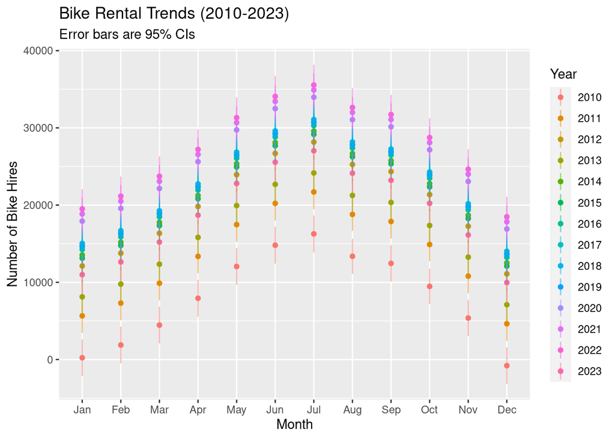

```r
# Visualize the data and review the trend of bike rents
ggplot(summary(m.hires.year.month.emm), aes(x=month, y=emmean, ymin=lower.CL, ymax=upper.CL, col=year)) + geom_point() + geom_linerange(alpha=0.5) + labs(x="Month", y="Number of Bike Hires", col="Year", title="Bike Rental Trends (2010-2023)",subtitle="Error bars are 95% CIs")
```

As we can see from this graph, bike rents are higher during the middle of the years and lower at the beginning and ending of the years. Take 2020 for example, the mean bike rents is 17923 with 95% CI[16055-19791] in January, and this figure increases all the way to 2020 July, with an average 33966 bike rents 95% CI[32050-35881]. Then, this figure decrease month by month to the end of the year, 2020 December, with an average bike rents of 16901 95% CI[15003-18799]. This trend can be seen in every year.

```r
# Year+Weekday

# Obtain the estimated mean value by using emmeans()
m.hires.year.day.emm <- emmeans(m.hires.time, ~year+day)

# Check the summary of the emmeans() and the mean values and confidence interval of each combination
summary(m.hires.year.day.emm)
```

```
##  year day emmean   SE   df lower.CL upper.CL
##  2010 Mon   7783 1181 4775     5467    10099
##  2011 Mon  13208 1105 4775    11041    15374
##  2012 Mon  19672 1105 4775    17506    21838
##  2013 Mon  15671 1105 4775    13504    17838
##  2014 Mon  21091 1105 4775    18925    23258
##  2015 Mon  20675 1105 4775    18508    22841
##  2016 Mon  21807 1105 4775    19640    23973
##  2017 Mon  22264 1105 4775    20098    24431
##  2018 Mon  22587 1105 4775    20421    24753
##  2019 Mon  22190 1105 4775    20024    24357
##  2020 Mon  25476  935 4775    23644    27308
##  2021 Mon  26409 1053 4775    24346    28473
##  2022 Mon  27055 1295 4775    24517    29593
##  2023 Mon  18539 1308 4775    15975    21104
```

[output cut: 87 more lines]

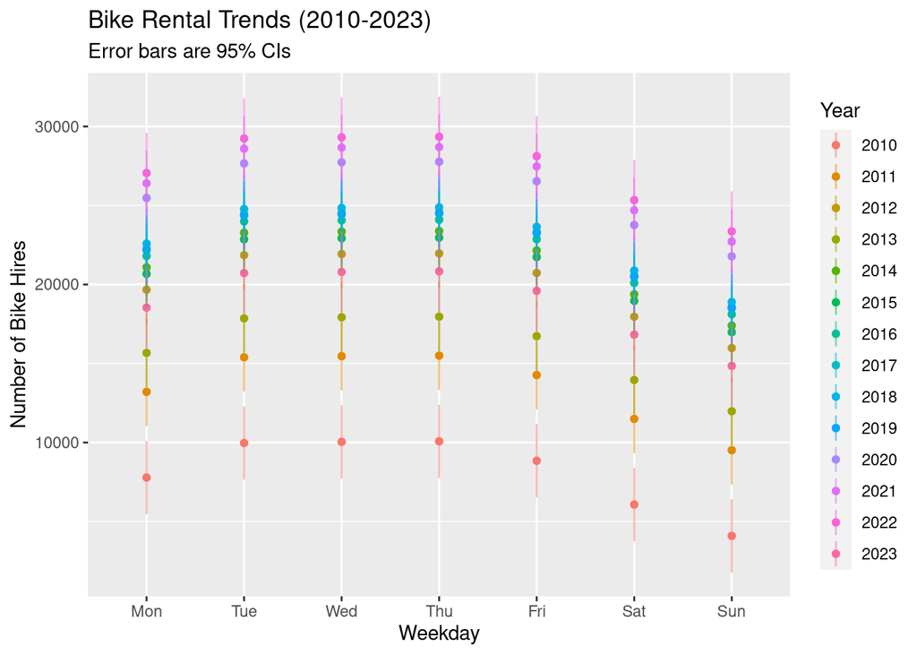

```r
# Visualize the data and review the trend of bike rents
ggplot(summary(m.hires.year.day.emm), aes(x=day, y=emmean, ymin=lower.CL, ymax=upper.CL, col=year)) + geom_point() + geom_linerange(alpha=0.5) + labs(x="Weekday", y="Number of Bike Hires", col="Year", title="Bike Rental Trends (2010-2023)",subtitle="Error bars are 95% CIs")
```

As we can see from this graph, bike rents are lower on weekends, which also reflects the negative coefficients of Saturday and Sunday in our regression model. Take 2023 for example, the mean bike rents is 18539 with 95% CI[15975-21104] on Monday, and this figure increases all the way to Thursday, with an average 20831 bike rents 95% CI[18266-23396]. Then, this figure decreases to the end of the week, Sunday, with an average bike rents of 14847 95% CI[12284-17410]. This trend can be seen in every year.

We then move on to assess the effect of the three policies we are interested in with and without time variables added:

```r
# Working from home
# Obtain the estimated mean value by using emmeans()
m.hires.wfh.time.emm <- emmeans(m.hires.time, ~wfh)

# Check the summary of the emmeans() and the mean values
summary(m.hires.wfh.time.emm)
```

```
##  wfh emmean   SE   df lower.CL upper.CL
##    0  21604 1120 4775    19409    23800
##    1  19711 1022 4775    17707    21716
##
## Results are averaged over the levels of: schools_closed, stay_at_home, curfew, eat_out_to_help_out, rule_of_6_indoors, year, month, day
## Confidence level used: 0.95
```

The mean bike rents when wfh equals to 0 (not practiced) is 21604 with 95% CI [19409-23800]; the mean bike rents when wfh equals to 1 (practiced) is 19711 with 95% CI [17707-21716], which is a decrease compare to the former situation.

```r
# Rule of 6 Indoors
# Obtain the estimated mean value by using emmeans()
m.hires.ro6.time.emm <- emmeans(m.hires.time, ~rule_of_6_indoors)

# Check the summary of the emmeans() and the mean values
summary(m.hires.ro6.time.emm)
```

```
##  rule_of_6_indoors emmean   SE   df lower.CL upper.CL
##                  0  20516  966 4775    18623    22409
##                  1  20800 1214 4775    18419    23180
##
## Results are averaged over the levels of: schools_closed, stay_at_home, curfew, eat_out_to_help_out, wfh, year, month, day
## Confidence level used: 0.95
```

The mean bike rents when rule_of_6_indoors equals to 0 (not practiced) is 20516 with 95% CI [18623-22409]; the mean bike rents when rule_of_6_indoors equals to 1 (practiced) is 20800 with 95% CI [18419-23180], which is a slight increase compare to the former situation.

```r
# Eat out to help out scheme
# Obtain the estimated mean value by using emmeans()
m.hires.eat.time.emm <- emmeans(m.hires.time, ~eat_out_to_help_out)

# Check the summary of the emmeans() and the mean values
summary(m.hires.eat.time.emm)
```

```
##  eat_out_to_help_out emmean   SE   df lower.CL upper.CL
##                    0  20976  735 4775    19536    22417
##                    1  20339 1558 4775    17285    23394
##
## Results are averaged over the levels of: schools_closed, stay_at_home, curfew, wfh, rule_of_6_indoors, year, month, day
## Confidence level used: 0.95
```

The mean bike rents when eat_out_to_help_out equals to 0 (not practiced) is 20976 with 95% CI [19536-22417]; the mean bike rents when rule_of_6_indoors equals to 1 (practiced) is 20339 with 95% CI [17285-23394], which is a slight decrease compare to the former situation.

We can compare the effect of the three policies with and without time variables added by using the visualization below:

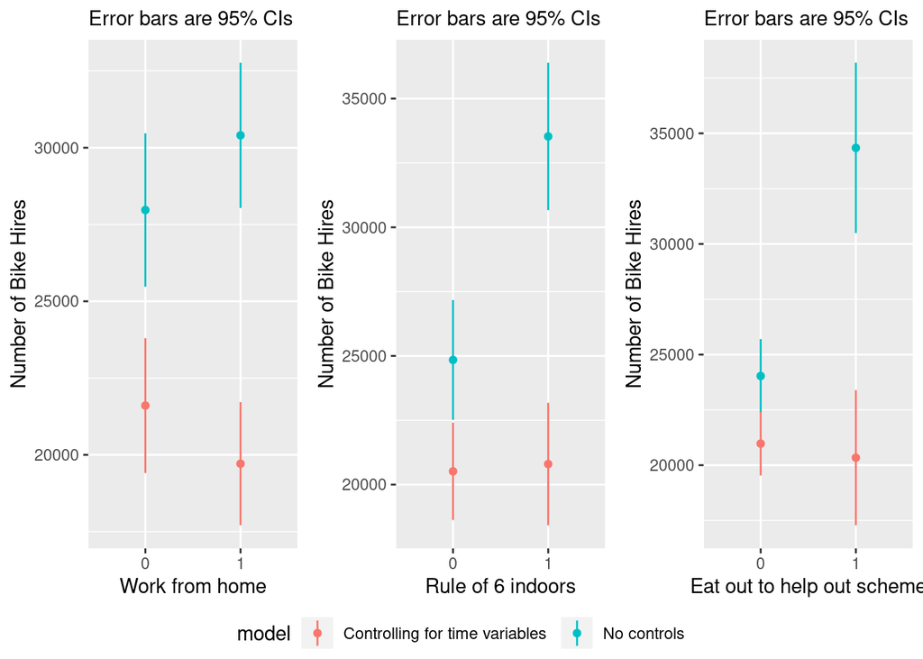

```r
# Combine two emmeans (with and without time variables) for each of the three variables
both.wfh.emms <- bind_rows(list(data.frame(m.hires.wfh.emm, model="No controls"), data.frame(m.hires.wfh.time.emm, model="Controlling for time variables")))

both.wfh.emms$wfh <- as.factor(both.wfh.emms$wfh)

both.ro6.emms <- bind_rows(list(data.frame(m.hires.ro6.emm, model="No controls"), data.frame(m.hires.ro6.time.emm, model="Controlling for time variables")))

both.ro6.emms$rule_of_6_indoors <- as.factor(both.ro6.emms$rule_of_6_indoors)

both.eat.emms <- bind_rows(list(data.frame(m.hires.eat.emm, model="No controls"), data.frame(m.hires.eat.time.emm, model="Controlling for time variables")))

both.eat.emms$eat_out_to_help_out <- as.factor(both.eat.emms$eat_out_to_help_out)


# Plot them together and compare the mean bike rents
ggarrange(ggplot(both.wfh.emms, aes(x=wfh, y=emmean, ymin=lower.CL, ymax=upper.CL, col=model)) + geom_point() + geom_linerange() + labs(x="Work from home", y="Number of Bike Hires", subtitle="Error bars are 95% CIs")  + scale_y_continuous(breaks = seq(15000, 40000, 5000)),
  ggplot(both.ro6.emms, aes(x=rule_of_6_indoors, y=emmean, ymin=lower.CL, ymax=upper.CL, col=model)) + geom_point() + geom_linerange() + labs(x="Rule of 6 indoors", y="Number of Bike Hires", subtitle="Error bars are 95% CIs")+ scale_y_continuous(breaks = seq(15000, 40000, 5000)),
  ggplot(both.eat.emms, aes(x=eat_out_to_help_out, y=emmean, ymin=lower.CL, ymax=upper.CL, col=model)) + geom_point() + geom_linerange() + labs(x="Eat out to help out scheme", y="Number of Bike Hires", subtitle="Error bars are 95% CIs")+ scale_y_continuous(breaks = seq(15000, 40000, 5000)), ncol=3, nrow=1, common.legend = TRUE, legend="bottom")
```

As we can see from this chart, after controlling time variables, the mean bike rents after the implementation of these policies are closer to the mean value before implementation, which is more reasonable and meaningful in terms of analyzing the effect of these variables. For example, with time variables controlled, the implementation of working from home will decrease the number of bike rents.

Finally, we can use a two-way ANOVA test to check if the regression model is significantly improved after introducing time variables.

```r
anova(m.hires, m.hires.time)
```

```
## Analysis of Variance Table
##
## Model 1: Hires ~ schools_closed + eating_places_closed + stay_at_home +
##     curfew + eat_out_to_help_out + wfh + rule_of_6_indoors
## Model 2: Hires ~ schools_closed + stay_at_home + curfew + eat_out_to_help_out +
##     wfh + rule_of_6_indoors + year + month + day
##   Res.Df        RSS Df  Sum of Sq      F    Pr(>F)
## 1   4804 4.2114e+11
## 2   4775 1.8851e+11 29 2.3262e+11 203.18 < 2.2e-16 ***
## ---
## Signif. codes:  0 '***' 0.001 '**' 0.01 '*' 0.05 '.' 0.1 ' ' 1
```

The ANOVA result shows that after adding time variables, the overall model fit is significantly improved (F(29,4775) = 203.18, p < 0.001).